# **Inteligencia Artificial I - Regreción Lineal**

### El siguiente es el codigo necesario para generar a partir de un dataset, un modelo de regreción lineal que pueda predecir el valor de cierto terreno.

```python
import pandas as pd
import numpy as np
import matplotlib.pyplot as plt
import seaborn as sns

casas = pd.read_csv('original.csv') #Este archivo es un dataset que se utilizara para hacer los ejercicios
```

```python
from sklearn.model_selection import train_test_split
from sklearn.linear_model import LinearRegression
```

Los valores utilizados para **x** son **los valores numericos**, mientras que el valor para **y** es **lo que se quiere saber**

```python
casas.columns
```

```
Index(['Avg. Area Income', 'Avg. Area House Age', 'Avg. Area Number of Rooms',
       'Avg. Area Number of Bedrooms', 'Area Population', 'Price', 'Address'],
      dtype='object')
```

Utilizaremos todas los parametros para x, y queremos saber el presio a futuro.

```python
x= casas[['Avg. Area Income', 'Avg. Area House Age', 'Avg. Area Number of Rooms',
       'Avg. Area Number of Bedrooms', 'Area Population']]
x
```

|  | Avg. Area Income | Avg. Area House Age | Avg. Area Number of Rooms | Avg. Area Number of Bedrooms | Area Population |
| --- | --- | --- | --- | --- | --- |
| 0 | 79545.458574 | 5.682861 | 7.009188 | 4.09 | 23086.800503 |
| 1 | 79248.642455 | 6.002900 | 6.730821 | 3.09 | 40173.072174 |
| 2 | 61287.067179 | 5.865890 | 8.512727 | 5.13 | 36882.159400 |
| 3 | 63345.240046 | 7.188236 | 5.586729 | 3.26 | 34310.242831 |
| 4 | 59982.197226 | 5.040555 | 7.839388 | 4.23 | 26354.109472 |
| ... | ... | ... | ... | ... | ... |
| 4995 | 60567.944140 | 7.830362 | 6.137356 | 3.46 | 22837.361035 |
| 4996 | 78491.275435 | 6.999135 | 6.576763 | 4.02 | 25616.115489 |
| 4997 | 63390.686886 | 7.250591 | 4.805081 | 2.13 | 33266.145490 |
| 4998 | 68001.331235 | 5.534388 | 7.130144 | 5.44 | 42625.620156 |
| 4999 | 65510.581804 | 5.992305 | 6.792336 | 4.07 | 46501.283803 |

5000 rows × 5 columns

```python
y = casas['Price']
y
```

```
0       1.059034e+06
1       1.505891e+06
2       1.058988e+06
3       1.260617e+06
4       6.309435e+05
            ...
4995    1.060194e+06
4996    1.482618e+06
4997    1.030730e+06
4998    1.198657e+06
4999    1.298950e+06
Name: Price, Length: 5000, dtype: float64
```

Es momento de entrenar la IA, entonces, declaramos que es lo que queremos entrenar y con que datos:

```python
x_train, x_test, y_train, y_test = train_test_split(x,y,test_size = 0.3,random_state = 42) #Utilizaremos el 30% de los datos para el test y el 70% para entrenar
```

```python
y
```

```
0       1.059034e+06
1       1.505891e+06
2       1.058988e+06
3       1.260617e+06
4       6.309435e+05
            ...
4995    1.060194e+06
4996    1.482618e+06
4997    1.030730e+06
4998    1.198657e+06
4999    1.298950e+06
Name: Price, Length: 5000, dtype: float64
```

```python
lrm = LinearRegression() #Creamos el objeto que hara la regresion lineal
lrm.fit(x_train,y_train) #Entrenamos el sistema
```

```
LinearRegression(copy_X=True, fit_intercept=True, n_jobs=None, normalize=False)
```

**Evaluamos Modelo**

```python
from sklearn import metrics
```

```python
predicciones = lrm.predict(x_test)
predicciones #Estos son los valores generados por la IA
```

```
array([1308536.1359262 , 1237122.72746477, 1243835.62817066, ...,
       1457119.79297242, 1483428.9530937 , 1047510.59737176])
```

```python
y_test #Estos son los valore reales
```

```
1501    1.339096e+06
2586    1.251794e+06
2653    1.340095e+06
1055    1.431508e+06
705     1.042374e+06
            ...
3563    1.348222e+06
1538    1.309937e+06
1837    1.472887e+06
2380    1.409762e+06
1912    1.009606e+06
Name: Price, Length: 1500, dtype: float64
```

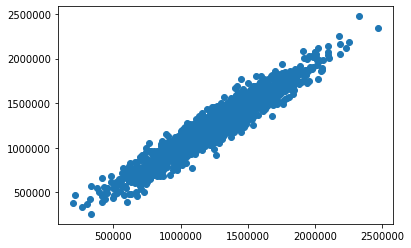

```python
plt.scatter(y_test,predicciones) #Esta es la diferencia entre los datos predecidos y los reales, entre más cerca de la linea esten, mejor es el sistema
```

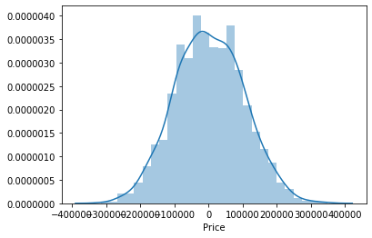

```python
sns.distplot(y_test - predicciones) #Es la diferencia entre los datos reales y los predecidos por la ia
```

Calculamos algunos valores que nos ayudaran a identificar errores en nuestra **IA**

**MEA (Mean Absolut Error)**: Media del valor absoluto de los errores

```python
metrics.mean_absolute_error(y_test,predicciones)
```

```
81135.56609336875
```

**MSE (Media de errores al cuadrado)**

```python
valor = metrics.mean_squared_error(y_test,predicciones)
valor
```

```
10068422551.401083
```

**RMSE**

```python
valor2 = np.sqrt(valor) #Le aplicamos raiz a lo anterior
valor2
```

```
100341.52954485537
```

Entre **más pequeño** es el número, mejor funciona nuestra **Inteligencia Artificial**